# Quiz 2 Practice - Questions

2025-10-15

> Use the pretrial_df dataset.

### 1. Visual EDA (5 points)

> Do visual EDA on the variables bail_amount and days_until_trial, jointly.

**Your code answer (5 points):**

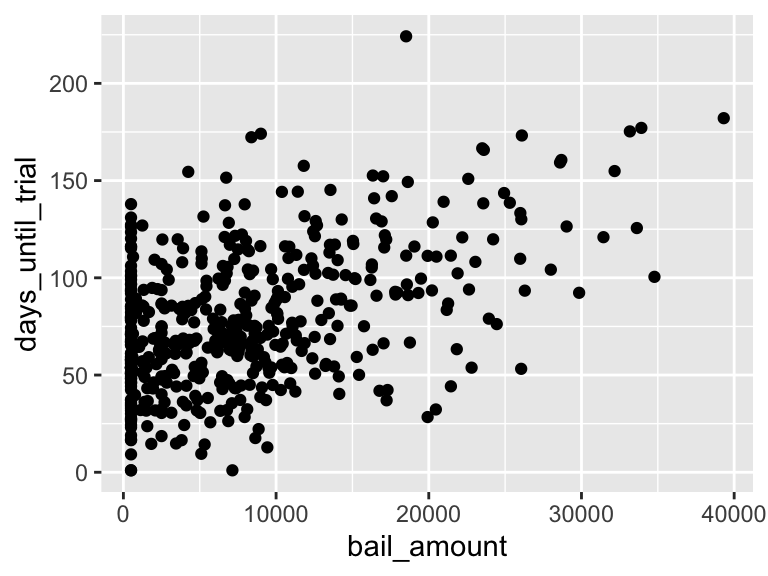

```r
dat %>% ggplot(aes(x=bail_amount, y=days_until_trial)) + geom_point()
```

**Your text answer (5 points):**

The scatterplot shows that the two variables have a positive association, a linear form (except for the truncation at 0), the relationship is not that strong, and there are some outliers, especially in high days until trial.

### 2. Quantitative EDA (5 points)

> Do quantitative EDA on the variables bail_amount and days_until_trial, jointly.

**Your code answer (5 points):**

```r
dat %>% summarize(correlation = cor(bail_amount, days_until_trial))
```

```
## # A tibble: 1 × 1
##   correlation
##         <dbl>
## 1       0.485
```

```r
dat %>% filter(days_until_trial < 200) %>% summarize(correlation = cor(bail_amount, days_until_trial))
```

```
## # A tibble: 1 × 1
##   correlation
##         <dbl>
## 1       0.482
```

**Your text answer (5 points):**

After checking that we are working with two quantitative variables, the relationship between the two variables is straight enough, we fit a correlation. There is at least an outlier in days_until_trial, so we provide the correlation with and without the outliers. The correlation went from 48.5% to 48.2%, so the outlier was not making a big difference.

### 3. Linear model fit (5 points)

> Fit a linear model that regresses bail_amount onto days_until_trial. Are the assumptions of linear regression met? Are there any influential outliers?

**Your code answer (5 points):**

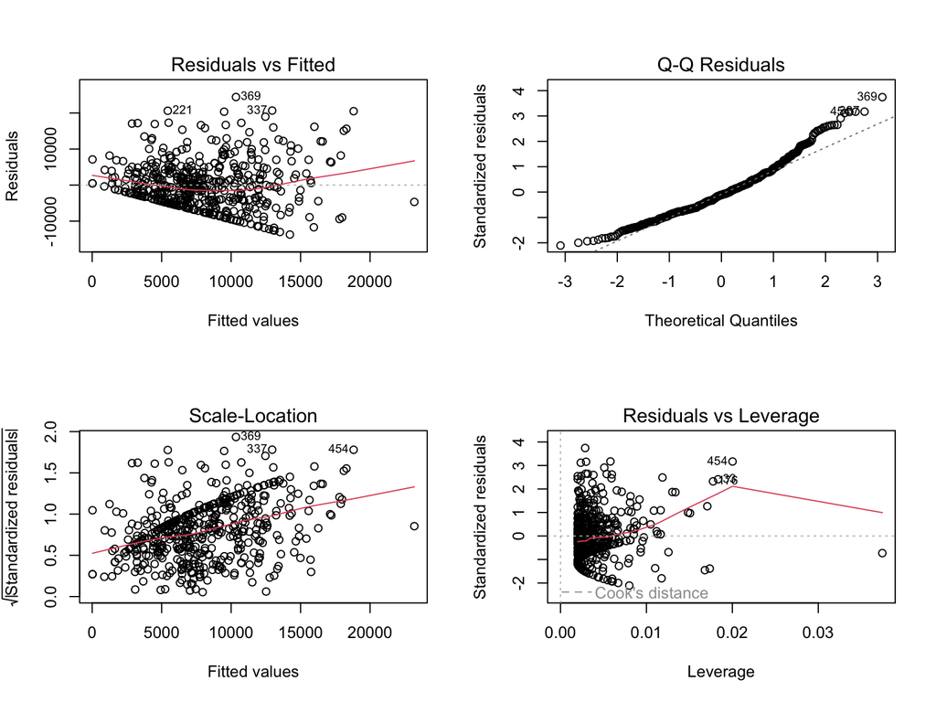

```r
out <- lm(bail_amount~days_until_trial, data=dat)
par(mfrow = c(2,2))
plot(out)
```

```r
par(mfrow = c(1,1))
```

### 4. Slope coefficient interpretation (5 points)

> Should you interpret the slope coefficient of the linear model?

**Your text answer (5 points):**

No because the model assumptions are not met. A linear regression is not the right model to fit here.